# Usemlr3

GuohuanZhang

2022/7/19

## R Markdown

This is the 3rd R Markdown document of GuohuanZhang.

### This R Markdown document aims to show how to use mlr3 and DALEX

### Find more at https://github.com/Thuoyuing/Thuoyuing.github.io

# 载入需要用到的包

```r
if(!require(pacman)){
  install.packages("pacman")
}
```

```r
pacman::p_load(tidyverse,  # 书写整洁的代码
               magrittr,   # 包含更多管道符——%<>%
               readxl,     # 读取 xlsx
               writexl,    # 输出xlsx
               mlr3verse,  # mlr3 机器学习模型库
               purrr,      # map
               DALEX,      # DALEX 模型解释
               ddpcr,      # 屏蔽提示消息
               ggplot2     # 画图
               )
```

# 读取数据

数据是我用rnorm()和sample()造出来的

可从我的github网页下载https://github.com/Thuoyuing/Thuoyuing.github.io/blob/main/element.xlsx

代码也可以下载https://github.com/Thuoyuing/Thuoyuing.github.io/blob/main/Usemlr3.R

```r
rm(list = ls())
read_xlsx("element.xlsx") -> data
data
```

```
## # A tibble: 300 x 14
##    ptbirth birthweight region   age weight height education smoking    As    Sr
##      <dbl>       <dbl> <chr>  <dbl>  <dbl>  <dbl>     <dbl>   <dbl> <dbl> <dbl>
##  1       0        3.33 North     22     55    180         1       0  24.0  62.1
##  2       0        3.50 North     25     54    162         3       1  19.4  66.8
##  3       0        3.36 North     30     56    158         1       1  30.0  66.1
##  4       0        3.56 North     29     61    180         1       1  22.2  66.8
##  5       0        3.44 South     20     65    153         1       0  26.3  76.7
##  6       0        3.52 South     23     76    170         3       0  28.1  63.3
##  7       0        3.58 South     22     54    156         2       1  23.6  58.4
##  8       0        3.40 South     30     67    167         3       0  26.2  58.2
##  9       0        3.19 North     24     70    176         3       1  25.8  59.1
## 10       0        3.45 South     24     67    164         1       0  25.5  58.8
## # ... with 290 more rows, and 4 more variables: B <dbl>, Al <dbl>, Th <dbl>,
## #   Ti <dbl>
```

今天用到：

birthweight——出生体重

中间的人口学特征

后面的母体血元素浓度

# 目的：建立预测新生儿出生体重的预测模型

在R中，mlr3的地位相当于Python中的sklearn，在机器学习中有非常强大的功能

既然不懂那些高深的算法，那就做一个快乐且潇洒的调包侠吧！

## 首先设置好机器学习的 task

出生体重是连续变量，所以这在mlr3中是一个回归问题

如果outcome是分类变量，那就是一个分类问题

–回归问题：as_task_regr()

–分类问题：as_task_classif()

```r
data %>%
  select(birthweight,
         age,
         weight,
         height,
         education,
         smoking,
         As:Ti) %>%
  as_task_regr(target = "birthweight",
               id = "birthweight") -> task.birthweight
```

## 然后设置好learner并调试参数

今天我们建立三种模型，并比较它们的准确性：

**弹性网络——正则化线性模型**

**随机森林——bagging集成的决策树模型**

**Xgboost——boosting集成的决策树模型**

什么是集成学习？https://rpubs.com/skydome20/R-Note16-Ensemble_Learning

不同的模型，有不同的参数，需要设置合适的参数，才可以训练出比较准确的模型

不知道怎么才能设置合适的参数？mlr3支持使用 autotune（不是说唱的那个！） 自动调参

### 首先是弹性网络模型

```r
learner.elastic.net = lrn("regr.glmnet",
                          predict_sets = c("train", "test"))
```

弹性网络需要优化的参数有两个：alpha和 lambda，它们共同决定了两个惩罚项的惩罚力度

这里设置这两个参数的调节范围都为0-1

```r
search_space = ps(
  alpha = p_dbl(lower = 0, upper = 1),
  lambda = p_dbl(lower = 0, upper = 1)
)
terminator = trm("evals", n_evals = 10)  # 10次迭代
tuner = tnr("random_search")             # 自调参的方法
```

mlr3中有四种自调参方法，包括：

**Random Search**

**Grid Search**

**Generalized Simulated Annealing**

**Non-Linear Optimization**

了解更多关于自调参的信息https://en.wikipedia.org/wiki/Hyperparameter_optimization

这里使用较简单的Random Search

适合在只有少量超参数影响机器学习算法的最终性能时使用

```r
at = AutoTuner$new(
  learner = learner.elastic.net,         # 需要调试参数的learner
  resampling = rsmp("cv", folds = 5),    # 使用5折交叉验证评价模型效果
  measure = msr("regr.mse"),             # 使用均方误差 mse 作为评价指标
  search_space = search_space,           # 调参范围
  terminator = terminator,               # 迭代方法
  tuner = tuner                          # 调参方法
)
at$train(task.birthweight)
```

[output not shown]

[output cut: 80 more lines]

[output not shown]

经过10次随机搜索，找到了均方误差 mse 最低的一次的模型的参数作为最优参数

如果不缺时间的话，可以增大次数，比如：

terminator = trm(“evals”, n_evals = 50)

查看参数优化的结果

```r
at$model$tuning_instance$result_learner_param_vals
```

```
## $family
## [1] "gaussian"
##
## $alpha
## [1] 0.3403907
##
## $lambda
## [1] 0.2352824
```

将learner的参数设置为刚刚优化出来的参数

```r
learner.elastic.net$param_set$values <- at$model$tuning_instance$result_learner_param_vals
learner.elastic.net$param_set
```

```
## <ParamSet>
##                       id    class lower upper nlevels        default parents
##  1:            alignment ParamFct    NA    NA       2         lambda
##  2:                alpha ParamDbl     0     1     Inf              1
##  3:                  big ParamDbl  -Inf   Inf     Inf        9.9e+35
##  4:               devmax ParamDbl     0     1     Inf          0.999
##  5:                dfmax ParamInt     0   Inf     Inf <NoDefault[3]>
##  6:                  eps ParamDbl     0     1     Inf          1e-06
##  7:                epsnr ParamDbl     0     1     Inf          1e-08
##  8:                exact ParamLgl    NA    NA       2          FALSE
##  9:              exclude ParamInt     1   Inf     Inf <NoDefault[3]>
## 10:                 exmx ParamDbl  -Inf   Inf     Inf            250
## 11:               family ParamFct    NA    NA       2       gaussian
## 12:                 fdev ParamDbl     0     1     Inf          1e-05
## 13:                gamma ParamDbl  -Inf   Inf     Inf              1   relax
## 14:              grouped ParamLgl    NA    NA       2           TRUE
## 15:            intercept ParamLgl    NA    NA       2           TRUE
## 16:                 keep ParamLgl    NA    NA       2          FALSE
## 17:               lambda ParamUty    NA    NA     Inf <NoDefault[3]>
## 18:     lambda.min.ratio ParamDbl     0     1     Inf <NoDefault[3]>
## 19:         lower.limits ParamUty    NA    NA     Inf <NoDefault[3]>
## 20:                maxit ParamInt     1   Inf     Inf         100000
## 21:                mnlam ParamInt     1   Inf     Inf              5
## 22:                 mxit ParamInt     1   Inf     Inf            100
## 23:               mxitnr ParamInt     1   Inf     Inf             25
## 24:            newoffset ParamUty    NA    NA     Inf <NoDefault[3]>
## 25:              nlambda ParamInt     1   Inf     Inf            100
## 26:               offset ParamUty    NA    NA     Inf
## 27:             parallel ParamLgl    NA    NA       2          FALSE
## 28:       penalty.factor ParamUty    NA    NA     Inf <NoDefault[3]>
## 29:                 pmax ParamInt     0   Inf     Inf <NoDefault[3]>
## 30:                 pmin ParamDbl     0     1     Inf          1e-09
## 31:                 prec ParamDbl  -Inf   Inf     Inf          1e-10
## 32:                relax ParamLgl    NA    NA       2          FALSE
## 33:                    s ParamDbl     0   Inf     Inf           0.01
## 34:          standardize ParamLgl    NA    NA       2           TRUE
## 35: standardize.response ParamLgl    NA    NA       2          FALSE
## 36:               thresh ParamDbl     0   Inf     Inf          1e-07
## 37:             trace.it ParamInt     0     1       2              0
## 38:        type.gaussian ParamFct    NA    NA       2 <NoDefault[3]>  family
```

[output cut: 32 more lines]

```
## 28:
## 29:
## 30:
## 31:
## 32:
## 33:
## 34:
## 35:
## 36:
## 37:
## 38:
## 39:
## 40:
## 41:
##         value
```

弹性网络的参数设置完成

### 随机森林模型

```r
learner.rf = lrn("regr.ranger",
                 predict_sets = c("train", "test"))
learner.rf$param_set
```

```
## <ParamSet>
##                               id    class lower upper nlevels        default
##  1:                        alpha ParamDbl  -Inf   Inf     Inf            0.5
##  2:       always.split.variables ParamUty    NA    NA     Inf <NoDefault[3]>
##  3:                      holdout ParamLgl    NA    NA       2          FALSE
##  4:                   importance ParamFct    NA    NA       4 <NoDefault[3]>
##  5:                   keep.inbag ParamLgl    NA    NA       2          FALSE
##  6:                    max.depth ParamInt     0   Inf     Inf
##  7:                min.node.size ParamInt     1   Inf     Inf              5
##  8:                     min.prop ParamDbl  -Inf   Inf     Inf            0.1
##  9:                      minprop ParamDbl  -Inf   Inf     Inf            0.1
## 10:                         mtry ParamInt     1   Inf     Inf <NoDefault[3]>
## 11:                   mtry.ratio ParamDbl     0     1     Inf <NoDefault[3]>
## 12:            num.random.splits ParamInt     1   Inf     Inf              1
## 13:                  num.threads ParamInt     1   Inf     Inf              1
## 14:                    num.trees ParamInt     1   Inf     Inf            500
## 15:                    oob.error ParamLgl    NA    NA       2           TRUE
## 16:                     quantreg ParamLgl    NA    NA       2          FALSE
## 17:        regularization.factor ParamUty    NA    NA     Inf              1
## 18:      regularization.usedepth ParamLgl    NA    NA       2          FALSE
## 19:                      replace ParamLgl    NA    NA       2           TRUE
## 20:    respect.unordered.factors ParamFct    NA    NA       3         ignore
## 21:              sample.fraction ParamDbl     0     1     Inf <NoDefault[3]>
## 22:                  save.memory ParamLgl    NA    NA       2          FALSE
## 23: scale.permutation.importance ParamLgl    NA    NA       2          FALSE
## 24:                    se.method ParamFct    NA    NA       2        infjack
## 25:                         seed ParamInt  -Inf   Inf     Inf
## 26:         split.select.weights ParamUty    NA    NA     Inf
## 27:                    splitrule ParamFct    NA    NA       3       variance
## 28:                      verbose ParamLgl    NA    NA       2           TRUE
## 29:                 write.forest ParamLgl    NA    NA       2           TRUE
##                               id    class lower upper nlevels        default
##        parents value
##  1:  splitrule
##  2:
##  3:
##  4:
##  5:
##  6:
##  7:
```

[output cut: 8 more lines]

```
## 16:
## 17:
## 18:
## 19:
## 20:
## 21:
## 22:
## 23: importance
## 24:
## 25:
## 26:
## 27:
## 28:
## 29:
##        parents value
```

随机森林主要需要优化3个参数

**max.depth——每棵树的最大深度**

**mtry.ratio——每次分叉时，使用多少比例的变量作为候选的分裂变量**

**num.trees——用于bagging集成的树的数量**

```r
search_space = ps(
  max.depth = p_int(lower = 6, upper = 100),
  mtry.ratio = p_dbl(lower = 0.3, upper = 0.7),
  num.trees = p_int(lower = 10, upper = 500)
)
terminator = trm("evals", n_evals = 10)
tuner = tnr("random_search")
at = AutoTuner$new(
  learner = learner.rf,
  resampling = rsmp("cv", folds = 5),
  measure = msr("regr.mse"),
  search_space = search_space,
  terminator = terminator,
  tuner = tuner
)
```

在刚刚调试弹性网络模型时，出现了很多提示信息，现在我们使用ddpcr::quiet()屏蔽掉这些没必要的信息

```r
ddpcr::quiet(at$train(task.birthweight))
learner.rf$param_set$values <- at$model$tuning_instance$result_learner_param_vals
learner.rf$param_set
```

```
## <ParamSet>
##                               id    class lower upper nlevels        default
##  1:                        alpha ParamDbl  -Inf   Inf     Inf            0.5
##  2:       always.split.variables ParamUty    NA    NA     Inf <NoDefault[3]>
##  3:                      holdout ParamLgl    NA    NA       2          FALSE
##  4:                   importance ParamFct    NA    NA       4 <NoDefault[3]>
##  5:                   keep.inbag ParamLgl    NA    NA       2          FALSE
##  6:                    max.depth ParamInt     0   Inf     Inf
##  7:                min.node.size ParamInt     1   Inf     Inf              5
##  8:                     min.prop ParamDbl  -Inf   Inf     Inf            0.1
##  9:                      minprop ParamDbl  -Inf   Inf     Inf            0.1
## 10:                         mtry ParamInt     1   Inf     Inf <NoDefault[3]>
## 11:                   mtry.ratio ParamDbl     0     1     Inf <NoDefault[3]>
## 12:            num.random.splits ParamInt     1   Inf     Inf              1
## 13:                  num.threads ParamInt     1   Inf     Inf              1
## 14:                    num.trees ParamInt     1   Inf     Inf            500
## 15:                    oob.error ParamLgl    NA    NA       2           TRUE
## 16:                     quantreg ParamLgl    NA    NA       2          FALSE
## 17:        regularization.factor ParamUty    NA    NA     Inf              1
## 18:      regularization.usedepth ParamLgl    NA    NA       2          FALSE
## 19:                      replace ParamLgl    NA    NA       2           TRUE
## 20:    respect.unordered.factors ParamFct    NA    NA       3         ignore
## 21:              sample.fraction ParamDbl     0     1     Inf <NoDefault[3]>
## 22:                  save.memory ParamLgl    NA    NA       2          FALSE
## 23: scale.permutation.importance ParamLgl    NA    NA       2          FALSE
## 24:                    se.method ParamFct    NA    NA       2        infjack
## 25:                         seed ParamInt  -Inf   Inf     Inf
## 26:         split.select.weights ParamUty    NA    NA     Inf
## 27:                    splitrule ParamFct    NA    NA       3       variance
## 28:                      verbose ParamLgl    NA    NA       2           TRUE
## 29:                 write.forest ParamLgl    NA    NA       2           TRUE
##                               id    class lower upper nlevels        default
##        parents     value
##  1:  splitrule
##  2:
##  3:
##  4:
##  5:
##  6:                   54
##  7:
```

[output cut: 8 more lines]

```
## 16:
## 17:
## 18:
## 19:
## 20:
## 21:
## 22:
## 23: importance
## 24:
## 25:
## 26:
## 27:
## 28:
## 29:
##        parents     value
```

随机森林的参数设置完成

### Xgboost 模型

```r
learner.xgb = lrn("regr.xgboost",
                  predict_sets = c("train", "test"))
learner.xgb$param_set
```

```
## <ParamSet>
##                              id    class lower upper nlevels          default
##  1:                       alpha ParamDbl     0   Inf     Inf                0
##  2:               approxcontrib ParamLgl    NA    NA       2            FALSE
##  3:                  base_score ParamDbl  -Inf   Inf     Inf              0.5
##  4:                     booster ParamFct    NA    NA       3           gbtree
##  5:                   callbacks ParamUty    NA    NA     Inf        <list[0]>
##  6:           colsample_bylevel ParamDbl     0     1     Inf                1
##  7:            colsample_bynode ParamDbl     0     1     Inf                1
##  8:            colsample_bytree ParamDbl     0     1     Inf                1
##  9: disable_default_eval_metric ParamLgl    NA    NA       2            FALSE
## 10:       early_stopping_rounds ParamInt     1   Inf     Inf
## 11:                         eta ParamDbl     0     1     Inf              0.3
## 12:                 eval_metric ParamUty    NA    NA     Inf             rmse
## 13:            feature_selector ParamFct    NA    NA       5           cyclic
## 14:                       feval ParamUty    NA    NA     Inf
## 15:                       gamma ParamDbl     0   Inf     Inf                0
## 16:                 grow_policy ParamFct    NA    NA       2        depthwise
## 17:     interaction_constraints ParamUty    NA    NA     Inf   <NoDefault[3]>
## 18:              iterationrange ParamUty    NA    NA     Inf   <NoDefault[3]>
## 19:                      lambda ParamDbl     0   Inf     Inf                1
## 20:                 lambda_bias ParamDbl     0   Inf     Inf                0
## 21:                     max_bin ParamInt     2   Inf     Inf              256
## 22:              max_delta_step ParamDbl     0   Inf     Inf                0
## 23:                   max_depth ParamInt     0   Inf     Inf                6
## 24:                  max_leaves ParamInt     0   Inf     Inf                0
## 25:                    maximize ParamLgl    NA    NA       2
## 26:            min_child_weight ParamDbl     0   Inf     Inf                1
## 27:                     missing ParamDbl  -Inf   Inf     Inf               NA
## 28:        monotone_constraints ParamUty    NA    NA     Inf                0
## 29:              normalize_type ParamFct    NA    NA       2             tree
## 30:                     nrounds ParamInt     1   Inf     Inf   <NoDefault[3]>
## 31:                     nthread ParamInt     1   Inf     Inf                1
## 32:                  ntreelimit ParamInt     1   Inf     Inf
## 33:           num_parallel_tree ParamInt     1   Inf     Inf                1
## 34:                   objective ParamUty    NA    NA     Inf reg:squarederror
## 35:                    one_drop ParamLgl    NA    NA       2            FALSE
## 36:                outputmargin ParamLgl    NA    NA       2            FALSE
## 37:                 predcontrib ParamLgl    NA    NA       2            FALSE
## 38:                   predictor ParamFct    NA    NA       2    cpu_predictor
```

[output cut: 78 more lines]

```
## 51:
## 52:              tree_method
## 53:              tree_method
## 54:                  booster
## 55:
## 56:
## 57: booster,feature_selector
## 58:
## 59:                  booster
## 60:                objective
## 61:
## 62:                              0
## 63:
## 64:
##                      parents value
```

Xgboost主要需要优化4个参数

**subsample——每次boosting抽取的总样本比例**

**colsample_bytree——同随机森林，每次分叉时使用的候选分裂变量占变量总数的比例**

**max_depth——同随机森林，每棵树的最大深度**

**nrounds——boosting的轮数**

```r
search_space = ps(
  subsample = p_dbl(lower = 0.5, upper = 1),
  colsample_bytree = p_dbl(lower = 0.5, upper = 1),
  max_depth = p_int(lower = 3, upper = 10),
  nrounds = p_int(lower = 2, upper = 200)
)
terminator = trm("evals", n_evals = 10)
tuner = tnr("random_search")
at = AutoTuner$new(
  learner = learner.xgb,
  resampling = rsmp("cv", folds = 5),
  measure = msr("regr.mse"),
  search_space = search_space,
  terminator = terminator,
  tuner = tuner
)
ddpcr::quiet(at$train(task.birthweight))
learner.xgb$param_set$values <- at$model$tuning_instance$result_learner_param_vals
learner.xgb$param_set
```

```
## <ParamSet>
##                              id    class lower upper nlevels          default
##  1:                       alpha ParamDbl     0   Inf     Inf                0
##  2:               approxcontrib ParamLgl    NA    NA       2            FALSE
##  3:                  base_score ParamDbl  -Inf   Inf     Inf              0.5
##  4:                     booster ParamFct    NA    NA       3           gbtree
##  5:                   callbacks ParamUty    NA    NA     Inf        <list[0]>
##  6:           colsample_bylevel ParamDbl     0     1     Inf                1
##  7:            colsample_bynode ParamDbl     0     1     Inf                1
##  8:            colsample_bytree ParamDbl     0     1     Inf                1
##  9: disable_default_eval_metric ParamLgl    NA    NA       2            FALSE
## 10:       early_stopping_rounds ParamInt     1   Inf     Inf
## 11:                         eta ParamDbl     0     1     Inf              0.3
## 12:                 eval_metric ParamUty    NA    NA     Inf             rmse
## 13:            feature_selector ParamFct    NA    NA       5           cyclic
## 14:                       feval ParamUty    NA    NA     Inf
## 15:                       gamma ParamDbl     0   Inf     Inf                0
## 16:                 grow_policy ParamFct    NA    NA       2        depthwise
## 17:     interaction_constraints ParamUty    NA    NA     Inf   <NoDefault[3]>
## 18:              iterationrange ParamUty    NA    NA     Inf   <NoDefault[3]>
## 19:                      lambda ParamDbl     0   Inf     Inf                1
## 20:                 lambda_bias ParamDbl     0   Inf     Inf                0
## 21:                     max_bin ParamInt     2   Inf     Inf              256
## 22:              max_delta_step ParamDbl     0   Inf     Inf                0
## 23:                   max_depth ParamInt     0   Inf     Inf                6
## 24:                  max_leaves ParamInt     0   Inf     Inf                0
## 25:                    maximize ParamLgl    NA    NA       2
## 26:            min_child_weight ParamDbl     0   Inf     Inf                1
## 27:                     missing ParamDbl  -Inf   Inf     Inf               NA
## 28:        monotone_constraints ParamUty    NA    NA     Inf                0
## 29:              normalize_type ParamFct    NA    NA       2             tree
## 30:                     nrounds ParamInt     1   Inf     Inf   <NoDefault[3]>
## 31:                     nthread ParamInt     1   Inf     Inf                1
## 32:                  ntreelimit ParamInt     1   Inf     Inf
## 33:           num_parallel_tree ParamInt     1   Inf     Inf                1
## 34:                   objective ParamUty    NA    NA     Inf reg:squarederror
## 35:                    one_drop ParamLgl    NA    NA       2            FALSE
## 36:                outputmargin ParamLgl    NA    NA       2            FALSE
## 37:                 predcontrib ParamLgl    NA    NA       2            FALSE
## 38:                   predictor ParamFct    NA    NA       2    cpu_predictor
```

[output cut: 78 more lines]

```
## 51:
## 52:              tree_method
## 53:              tree_method
## 54:                  booster
## 55:
## 56:                          0.8440208
## 57: booster,feature_selector
## 58:
## 59:                  booster
## 60:                objective
## 61:
## 62:                                  0
## 63:
## 64:
##                      parents     value
```

Xgboost模型的参数设置完成

## 模型评价

使用mlr3中的benchmark来比较各个模型的预测能力

```r
design = benchmark_grid(
  tasks = task.birthweight,
  learners = c(learner.elastic.net,
               learner.rf,
               learner.xgb),
  resamplings = rsmp("cv", folds = 5))
benchmark(design) -> bmr
```

[output not shown]

bmr设置完成后，可以按照指定的评价指标，展示模型优劣

我们这里依然使用均方误差 mse 作为指标

查看5折交叉的训练集与测试集的mse

```r
list(msr("regr.mse", predict_sets = "train", id = "mse_train"),
     msr("regr.mse", predict_sets = "test", id ="mse_test")) -> measures_bmr
bmr$aggregate(measures_bmr)
```

```
##    nr      resample_result     task_id   learner_id resampling_id iters
## 1:  1 <ResampleResult[22]> birthweight  regr.glmnet            cv     5
## 2:  2 <ResampleResult[22]> birthweight  regr.ranger            cv     5
## 3:  3 <ResampleResult[22]> birthweight regr.xgboost            cv     5
##       mse_train   mse_test
## 1: 5.001425e-02 0.05039175
## 2: 2.951655e-03 0.01722195
## 3: 2.396629e-07 0.02343213
```

也可以画图

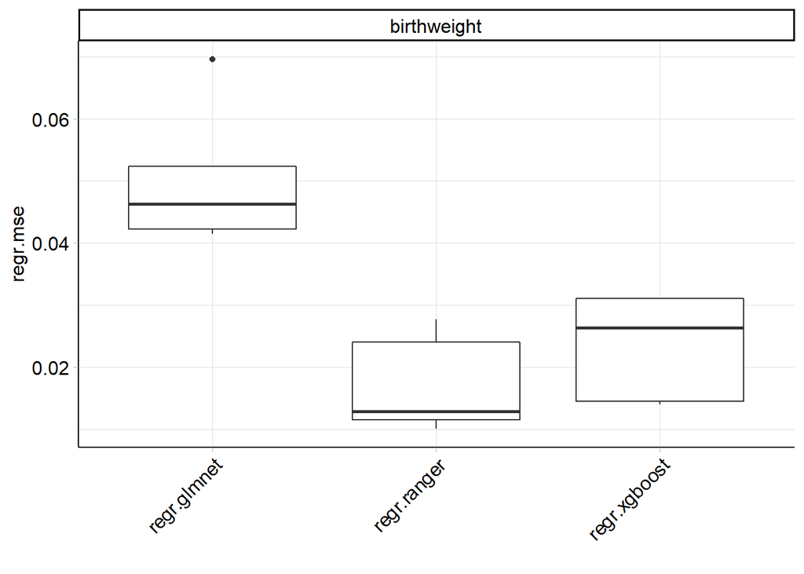

```r
bmr %>% autoplot(type = "boxplot")
```

如果是分类问题，还可以画roc曲线等

可以看到随机森林模型的误差更低

因此我们最后建立随机森林模型

```r
learner.rf$train(task.birthweight)
```

## 模型解释

模型建立完成了，但是我好像什么都没得到

原因是这种集成树模型是类似黑盒的东西，不会像线性模型一样给你回归系数和假设检验的P值

但是我们仍然有方法去“开盒”，进而理解和解释模型

这里使用DALEX包，进行模型解释：

需要先设置一个随机森林模型的explainer

```r
expl_rf <- DALEX::explain(model = learner.rf,
                          data = data %>% select(task.birthweight$feature_names) %>% as.data.frame(),
                          y = data$birthweight,
                          label = "Randomforest")
```

```
## Preparation of a new explainer is initiated
##   -> model label       :  Randomforest
##   -> data              :  300  rows  11  cols
##   -> target variable   :  300  values
##   -> predict function  :  yhat.default will be used (  default  )
##   -> predicted values  :  No value for predict function target column. (  default  )
##   -> model_info        :  package Model of class: LearnerRegrRanger package unrecognized , ver. Unknown , task regression (  default  )
##   -> predicted values  :  numerical, min =  1.879017 , mean =  2.665887 , max =  3.615608
##   -> residual function :  difference between y and yhat (  default  )
##   -> residuals         :  numerical, min =  -0.2734985 , mean =  -0.0005237653 , max =  0.3148605
##   A new explainer has been created!
```

首先查看变量重要性，既各个变量在模型预测过程中的重要性

一般是用去除该变量后模型增加的误差来评价的

如果去除这个变量，模型会增加很大的误差，那说明这个变量很重要

反之则说明这个变量不重要

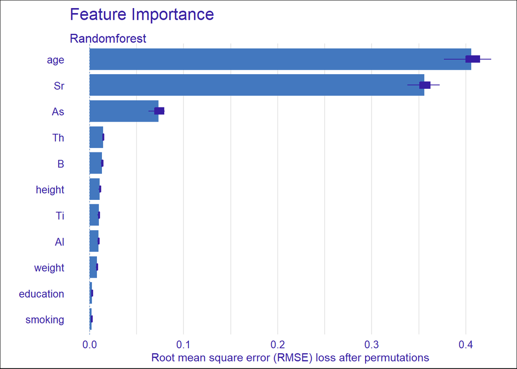

```r
DALEX::model_parts(explainer = expl_rf,
            loss_function = loss_default(expl_rf$model_info$type),
            B=10,
            type = "difference") -> importance.rf
importance.rf %>%
  plot()+
  theme(plot.background = element_rect(fill = 'white'))+
  ggtitle("Feature Importance",
          "")
```

可以看到age, Sr, As三个变量最重要

那么这些变量是怎么影响预测值的呢？

DALEX提供一种叫**Partial-dependence plot**的图

我们使用**purrr::map**，对**age, Sr, As**三个变量的**Partial-dependence plot**进行批量绘图

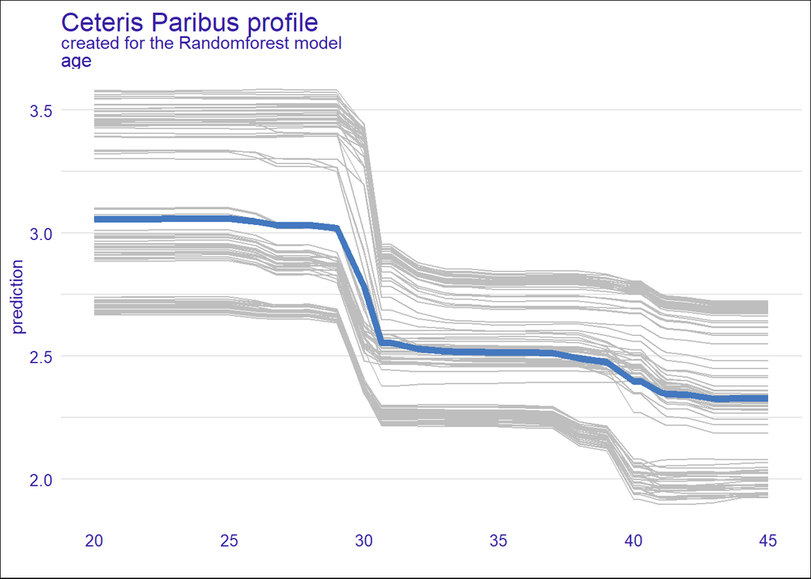

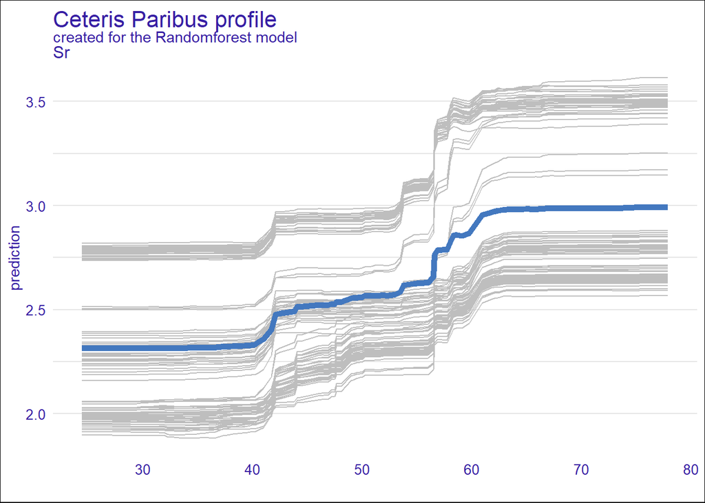

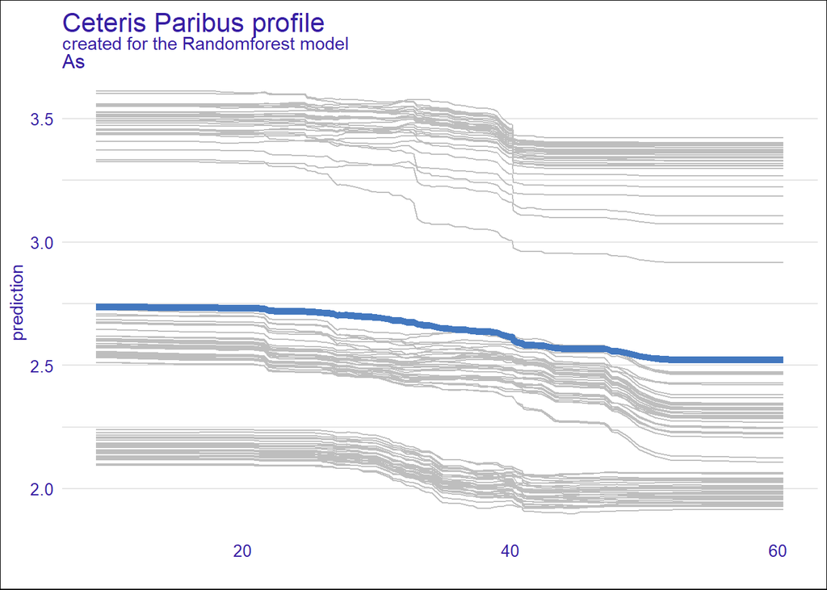

```r
Pdplot <- function(feature){
  DALEX::model_profile(explainer = expl_rf,
                       variables = feature) %>%
    plot(geom = "profiles")+
    theme(plot.background = element_rect(fill = 'white'))
}
map(c("age","Sr","As"),    # 对 "age" "Sr" "As"
    Pdplot)                # 都执行 Pdplot
```

可以看到：

**随着母亲年龄的增加，新生儿出生体重的预测值在母亲到30岁时明显降低**

**随着母体血Sr浓度的增加，新生儿出生体重的预测值不断上升,在55 ng/mL时最明显**

**随着母体血As浓度的增加，新生儿出生体重的预测值不断降低**

## 预测

别忘了我们的初衷————建立预测模型，目的当然是**预测**

我们可以对原有数据进行预测，并比较预测值(response)与真实值(truth)：

```r
learner.rf$predict(task.birthweight)
```

```
## <PredictionRegr> for 300 observations:
##     row_ids    truth response
##           1 3.332349 3.387835
##           2 3.499089 3.498423
##           3 3.356251 3.344138
## ---
##         298 2.085704 2.051196
##         299 2.114433 2.093191
##         300 1.957254 1.959268
```

也可以对新的数据集进行预测

一般是成功建立模型后，再继续收集新的研究对象。

然后在新研究对象还没有发生结局的时候预测他们的结局。

进而提前做出相应的措施，应对可能的健康风险

由于数据是我造的，没有新数据，我也懒得再造，就假装原数据的前50行是新数据吧：

```r
data %>%
  select(age,
         weight,
         height,
         education,
         smoking,
         As:Ti) %>%
  head(50) -> newdata
learner.rf$predict_newdata(newdata)
```

```
## <PredictionRegr> for 50 observations:
##     row_ids truth response
##           1    NA 3.387835
##           2    NA 3.498423
##           3    NA 3.344138
## ---
##          48    NA 3.476578
##          49    NA 3.512585
##          50    NA 3.424020
```

由于这是新数据，结局还没有发生，所以truth那一列都是NA

## 其他问题

分类问题：

```r
data %>%
  select(ptbirth,
         age,
         weight,
         height,
         education,
         smoking,
         As:Ti) %>%
  mutate(ptbirth = as.factor(ptbirth)) %>%
  as_task_classif(target = "ptbirth",
                  id = "ptbirth") -> task.ptbirth
learner.rf = lrn("classif.ranger",
                 predict_sets = c("train", "test"))
```

生存分析：

```r
# data %>%
#   as_task_surv(time = time.Y,
#                event= event.Y,
#                type= 'right') -> task.surv
# learner.rf = lrn("surv.ranger")
```

## mlr3中还有哪些模型可以用? Keyword是什么？

```r
mlr_learners$keys()
```

```
##   [1] "classif.AdaBoostM1"   "classif.bart"         "classif.C50"
##   [4] "classif.catboost"     "classif.cforest"      "classif.ctree"
##   [7] "classif.cv_glmnet"    "classif.debug"        "classif.earth"
##  [10] "classif.extratrees"   "classif.featureless"  "classif.fnn"
##  [13] "classif.gam"          "classif.gamboost"     "classif.gausspr"
##  [16] "classif.gbm"          "classif.glmboost"     "classif.glmnet"
##  [19] "classif.IBk"          "classif.J48"          "classif.JRip"
##  [22] "classif.kknn"         "classif.ksvm"         "classif.lda"
##  [25] "classif.liblinear"    "classif.lightgbm"     "classif.LMT"
##  [28] "classif.log_reg"      "classif.lssvm"        "classif.mob"
##  [31] "classif.multinom"     "classif.naive_bayes"  "classif.nnet"
##  [34] "classif.OneR"         "classif.PART"         "classif.qda"
##  [37] "classif.randomForest" "classif.ranger"       "classif.rfsrc"
##  [40] "classif.rpart"        "classif.svm"          "classif.xgboost"
##  [43] "clust.agnes"          "clust.ap"             "clust.cmeans"
```

[output cut: 31 more lines]

## 提醒

mlr3和DALEX还有很多内容

除了可用均方误差 mse 评价外，还可以用rmse, rsq, sse等等指标

分类问题还可用分类误差ce, aic, bic等指标

除了交叉验证，还可以用：

leave-one-out

boostrapping

houlout等等……

DALEX还可以在个体水平上进行解释——某一个人的预测值，主要有哪些变量的贡献，贡献各占多少等等

这里只展示了一小部分内容

### 如果对mlr3和DALEX感兴趣，可以联系总欢，总欢发教材给你

# Over————————————————————

特别鸣谢：

给我点赞的你们